# Course Project Description

# Suggested outline

In this project, you may utilize the template provided in the practice project as a guide. However, it is important to note that for consistency in grading, the final report must include all seven parts listed below, specifically an abstract and six main sections.

- Abstract.
- Introduction.
- Background. Review and provide basic background of the experiment.
- Descriptive analysis. Explore the dataset and generate summary statistics and plots that you find informative, and explain your findings. Additionally, you should explicitly address the unique feature of this dataset, which is that each session contains varying numbers of neurons. An important task in this analysis is to define the outcome variable. One suggested approach is to use the mean firing rate, which is calculated as, for each trial, the average number of spikes per second across all neurons within a given 0.4 seconds time interval. However, even if this suggestion is followed, it is crucial that your report contains justification of this choice.

```r
library(ggplot2)
library(GGally)
# Obtain the firing rate
# averaged over [0,0.4] seconds since stim onsets
# averaged across all neurons

ID=1
t=0.4 # from Background

n.trials=length(session[[ID]]$spks)
n.neurons=dim(session[[ID]]$spks[[1]])[1]

# Obtain the firing rate
firingrate=numeric(n.trials)
for(i in 1:n.trials){
  firingrate[i]=sum(session[[ID]]$spks[[i]])/n.neurons/t
}
```

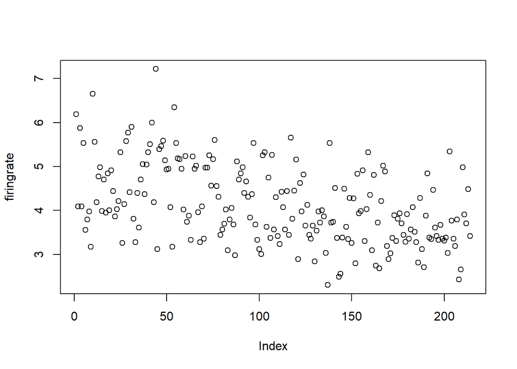

```r
plot(firingrate)
```

```r
s = list()
data = data.frame(NULL)

for (ID in 1:5) {
  n.trials = length(session[[ID]]$spks)
  n.neurons = dim(session[[ID]]$spks[[1]])[1]

  # Obtain the firing rate
  firingrate = numeric(n.trials)
  for (i in 1:n.trials) {
    firingrate[i] = sum(session[[ID]]$spks[[i]]) / n.neurons / 0.4
  }

  # List of DataFrame for each session
  s[[ID]] = data.frame(
    session = as.factor(ID),
    date = as.factor(session[[ID]]$date_exp),
    name = as.factor(session[[ID]]$mouse_name),
    contrast_left = as.factor(session[[ID]]$contrast_left),
    contrast_right = as.factor(session[[ID]]$contrast_right),
    feedback_type = as.factor(session[[ID]]$feedback_type),
    firingrate = firingrate
  )

  # Append to main DataFrame
  data = rbind(data, s[[ID]])
}
```

```r
str(data)
```

```
## 'data.frame':    1196 obs. of  7 variables:
##  $ session       : Factor w/ 5 levels "1","2","3","4",..: 1 1 1 1 1 1 1 1 1 1 ...
##  $ date          : Factor w/ 5 levels "2016-12-14","2016-12-17",..: 1 1 1 1 1 1 1 1 1 1 ...
##  $ name          : Factor w/ 2 levels "Cori","Forssmann": 1 1 1 1 1 1 1 1 1 1 ...
##  $ contrast_left : Factor w/ 4 levels "0","0.25","0.5",..: 4 1 4 1 3 1 1 1 1 4 ...
##  $ contrast_right: Factor w/ 4 levels "0","0.25","0.5",..: 1 3 3 1 4 1 1 1 1 3 ...
##  $ feedback_type : Factor w/ 2 levels "-1","1": 2 2 2 2 1 1 1 1 2 2 ...
##  $ firingrate    : num  6.19 4.09 5.87 4.09 5.53 ...
```

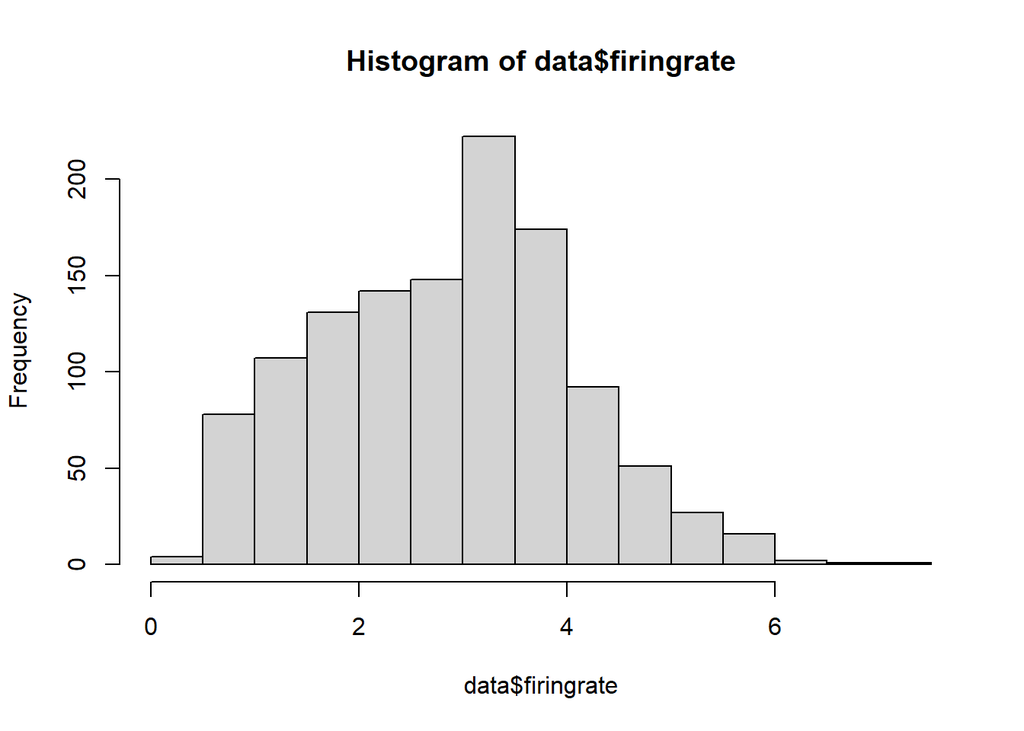

```r
hist(data$firingrate)
```

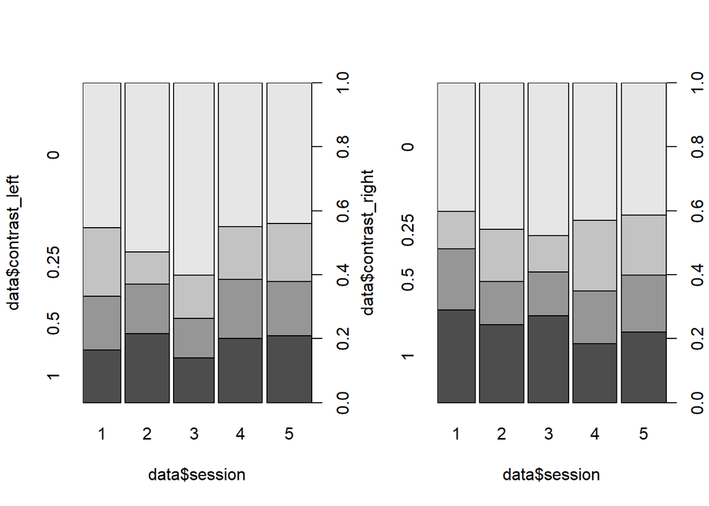

```r
par(mfrow = c(1,2))
plot(data$contrast_left ~ data$session)
plot(data$contrast_right ~ data$session)
```

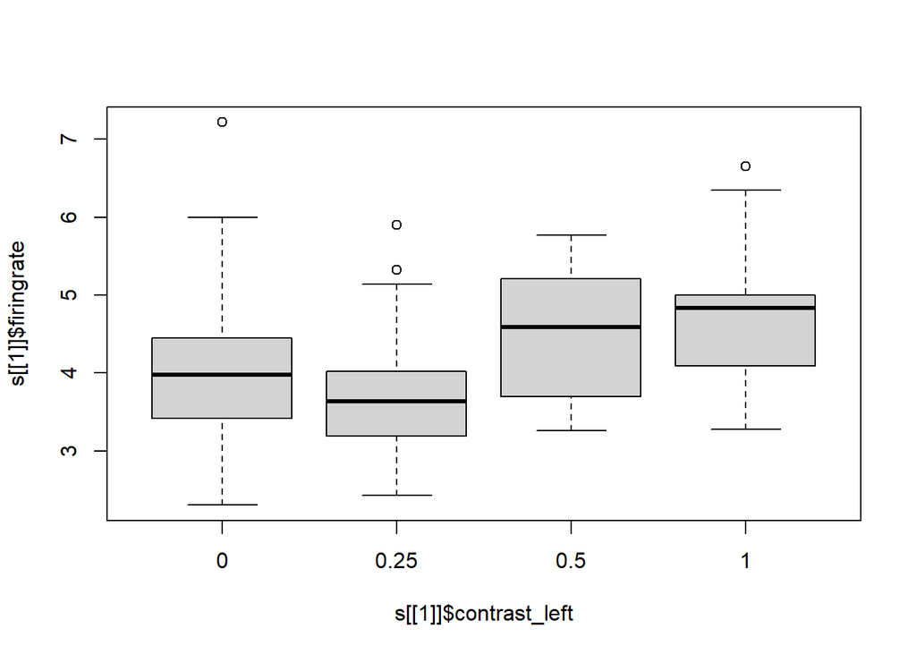

```r
boxplot(s[[1]]$firingrate ~ s[[1]]$contrast_left)
```

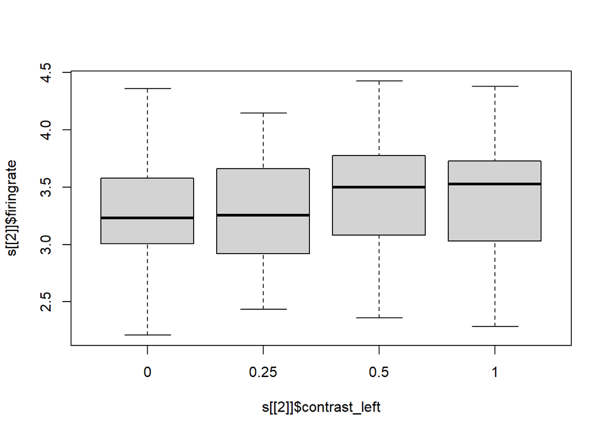

```r
boxplot(s[[2]]$firingrate ~ s[[2]]$contrast_left)
```

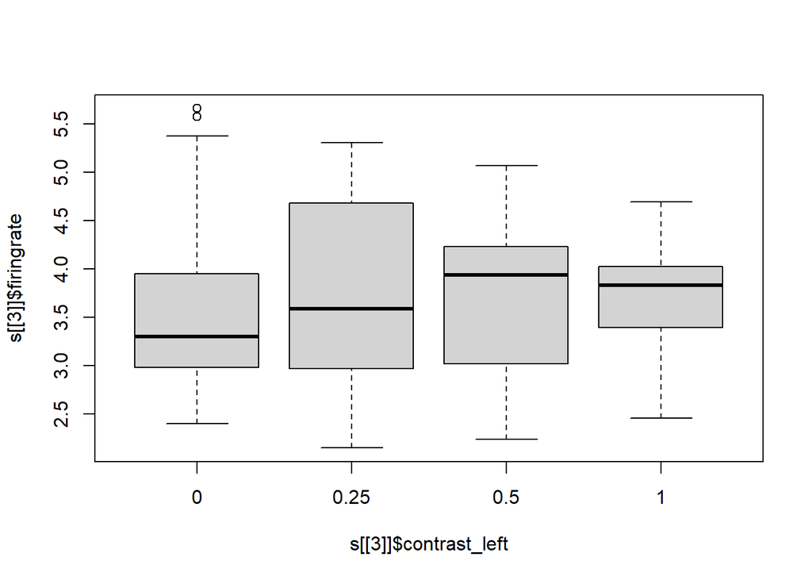

```r
boxplot(s[[3]]$firingrate ~ s[[3]]$contrast_left)
```

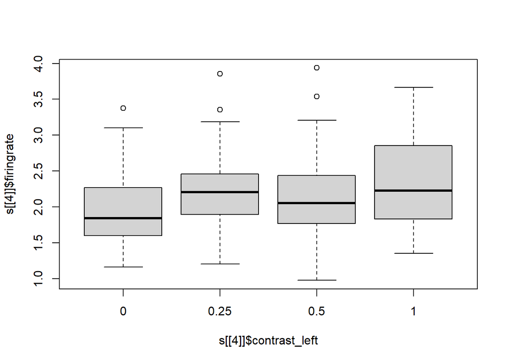

```r
boxplot(s[[4]]$firingrate ~ s[[4]]$contrast_left)
```

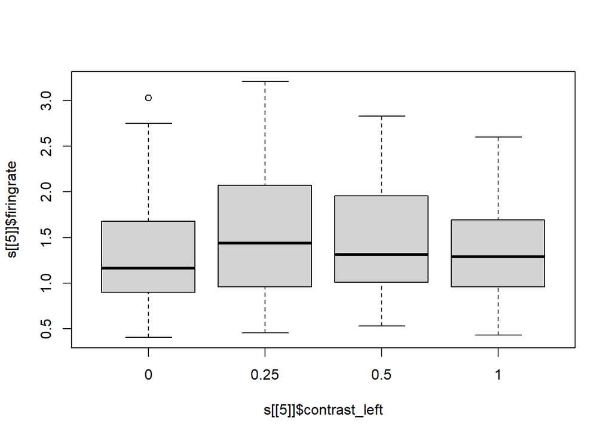

```r
boxplot(s[[5]]$firingrate ~ s[[5]]$contrast_left)
```

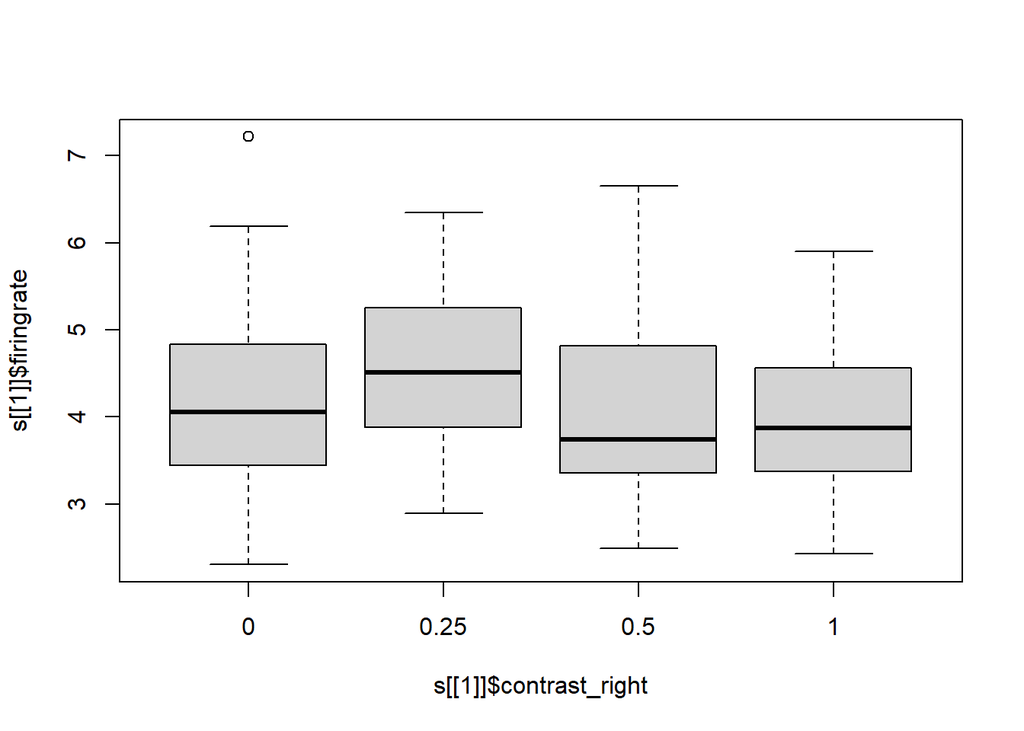

```r
boxplot(s[[1]]$firingrate ~ s[[1]]$contrast_right)
```

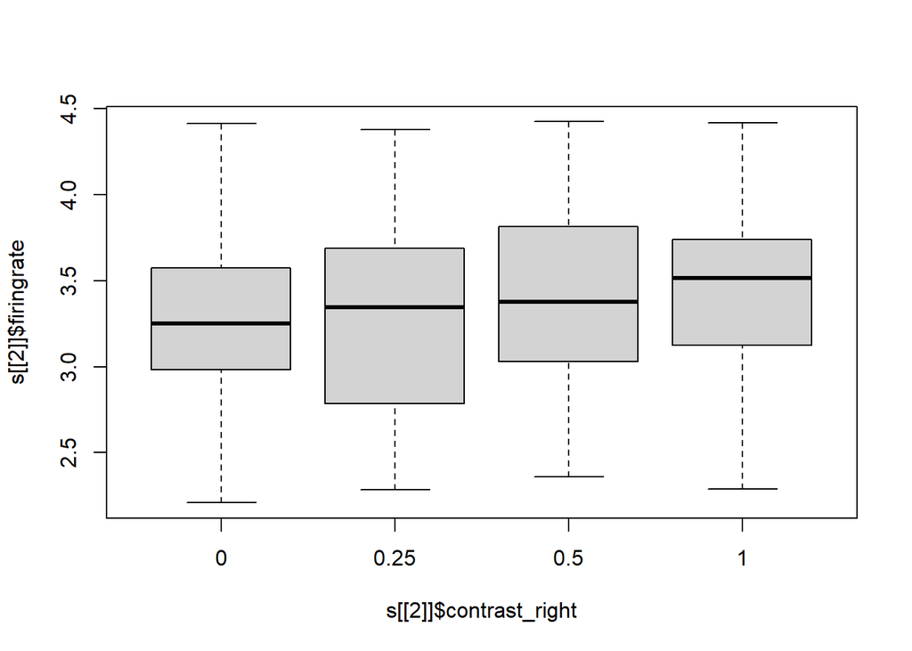

```r
boxplot(s[[2]]$firingrate ~ s[[2]]$contrast_right)
```

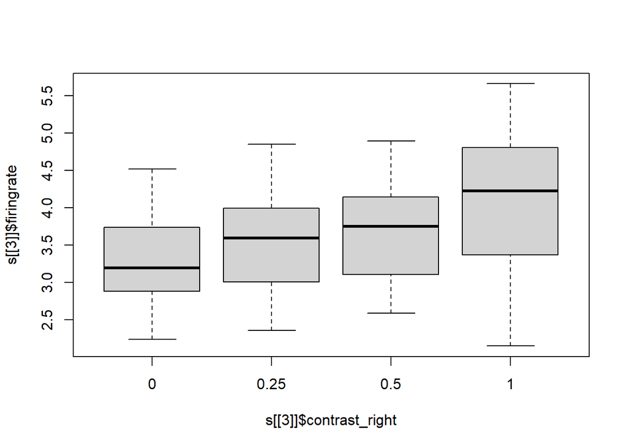

```r
boxplot(s[[3]]$firingrate ~ s[[3]]$contrast_right)
```

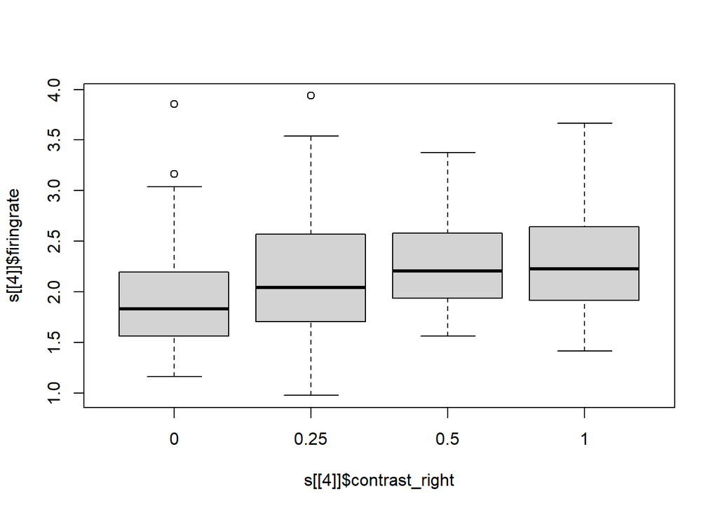

```r
boxplot(s[[4]]$firingrate ~ s[[4]]$contrast_right)
```

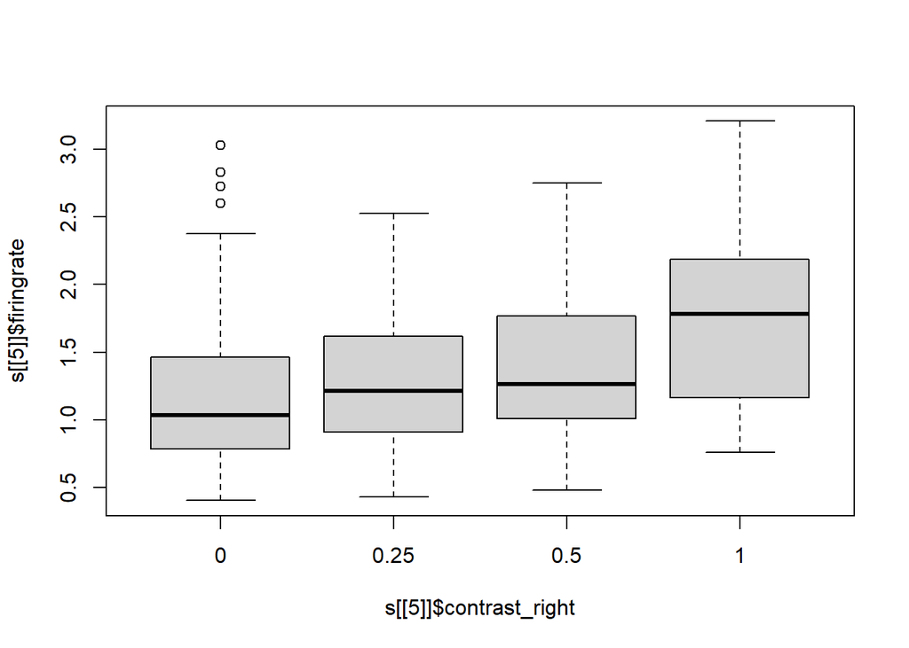

```r
boxplot(s[[5]]$firingrate ~ s[[5]]$contrast_right)
```

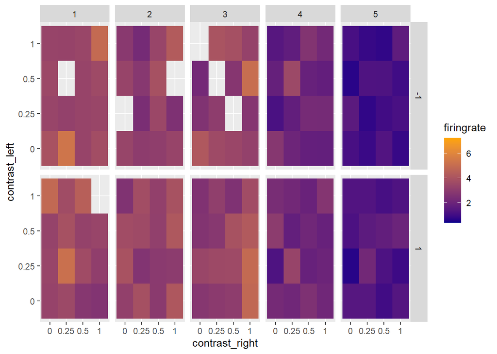

```r
ggplot(data, aes(contrast_right, contrast_left, fill = firingrate)) +
  geom_tile() +
  facet_grid(feedback_type ~ session) +
  scale_fill_gradient(low="blue4", high="orange")
```

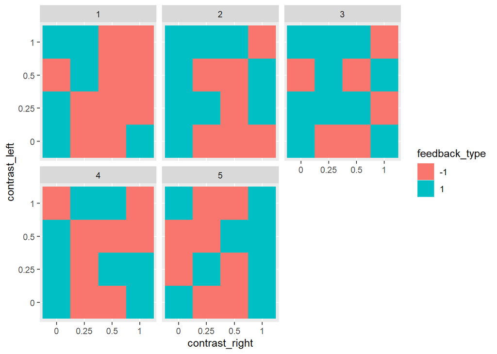

```r
ggplot(data, aes(contrast_right, contrast_left, fill = feedback_type)) +
  geom_tile() +
  facet_wrap(~ session)
```

- Inferential analysis (Q1). Consider a mixed effect model where the two fixed-effect factors are left contrast and right contrast, and a random intercept is included for each session. As a result, Q1 reduces to test the null hypothesis that the two factors have no interaction effect.
- Sensitivity analysis (Q1). Conduct model diagnostics and/or sensitivity analysis. In addition to the regular diagnostics, you should examine whether one need to account for the random effects from sessions. You may also explore using other statistics as outcomes.
- Predictive modeling (Q2). Make sure that you do not use the first 100 trials in Session 1 in model training.

# Reference

Steinmetz, N.A., Zatka-Haas, P., Carandini, M. et al. Distributed coding of choice, action and engagement across the mouse brain. Nature 576, 266–273 (2019). https://doi.org/10.1038/s41586-019-1787-x